# Function Documentation

### examples

```r
library(ggplot2)
library(reshape2)
data(cd4)
```

We will work with the same cd4 matrix, containing one functional observation in each row, used in the Refund package.

```r
cd4_tfd = cd4 %>%
  tfd()
cd4_df = data_frame(cd4_tfd)

head(cd4_df)
```

```
## # A tibble: 6 x 1
##   cd4_tfd
##   <S3: tfd_irreg>
## 1 [1]: ( -9, 548);( -3, 893);(  3, 657)
## 2 [2]: ( -3, 752);(  3, 459);(  9, 181); ...
## 3 [3]: (-15, 846);( -9,1102);( -3, 801); ...
## 4 [4]: (-17,1277);( -9,1132);( -3,1454); ...
## 5 [5]: ( -4, 994);(  4, 486);( 10, 605); ...
## 6 [6]: (-17,1119);(-10, 729);( 10, 355)
```

I altered the cd4 matrix to be in a tfd format. Then made it into a dataframe with only one column: cd4_tfd.

```r
source("./function/quadWeights.R")
source("./function/fpca.tfd.R")
```

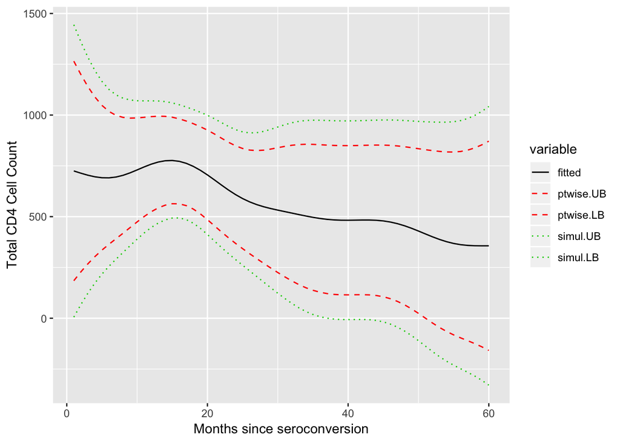

```r
fit.cd4 = fpca.tfd(data = cd4_df, col = cd4_tfd, var = TRUE, simul = TRUE)

fit.mu = data.frame(mu = fit.cd4$mu,
                    n = 1:ncol(fit.cd4$Yhat))
fit.basis = data.frame(phi = fit.cd4$efunctions, #the FPC basis functions.
                       n = 1:ncol(fit.cd4$Yhat))

## for one subject, examine curve estimate, pointwise and simultaneous itervals
ex = 1
ex.cd4 = data.frame(fitted = fit.cd4$Yhat[ex,],
           ptwise.UB = fit.cd4$Yhat[ex,] + 1.96 * sqrt(fit.cd4$diag.var[ex,]),
           ptwise.LB = fit.cd4$Yhat[ex,] - 1.96 * sqrt(fit.cd4$diag.var[ex,]),
           simul.UB = fit.cd4$Yhat[ex,] + fit.cd4$crit.val[ex] * sqrt(fit.cd4$diag.var[ex,]),
           simul.LB = fit.cd4$Yhat[ex,] - fit.cd4$crit.val[ex] * sqrt(fit.cd4$diag.var[ex,]),
           n = 1:ncol(fit.cd4$Yhat))

## plot data for one subject, with curve and interval estimates
ex.cd4.m = melt(ex.cd4, id = 'n')

## plot data for one subject, with curve and interval estimates
ex.cd4.m = melt(ex.cd4, id = 'n')
ggplot(ex.cd4.m, aes(x = n, y = value, group = variable, color = variable, linetype = variable)) +
  geom_path() +
  scale_linetype_manual(values = c(fitted = 1, ptwise.UB = 2,
                        ptwise.LB = 2, simul.UB = 3, simul.LB = 3)) +
  scale_color_manual(values = c(fitted = 1, ptwise.UB = 2,
                     ptwise.LB = 2, simul.UB = 3, simul.LB = 3)) +
  labs(x = 'Months since seroconversion', y = 'Total CD4 Cell Count')
```

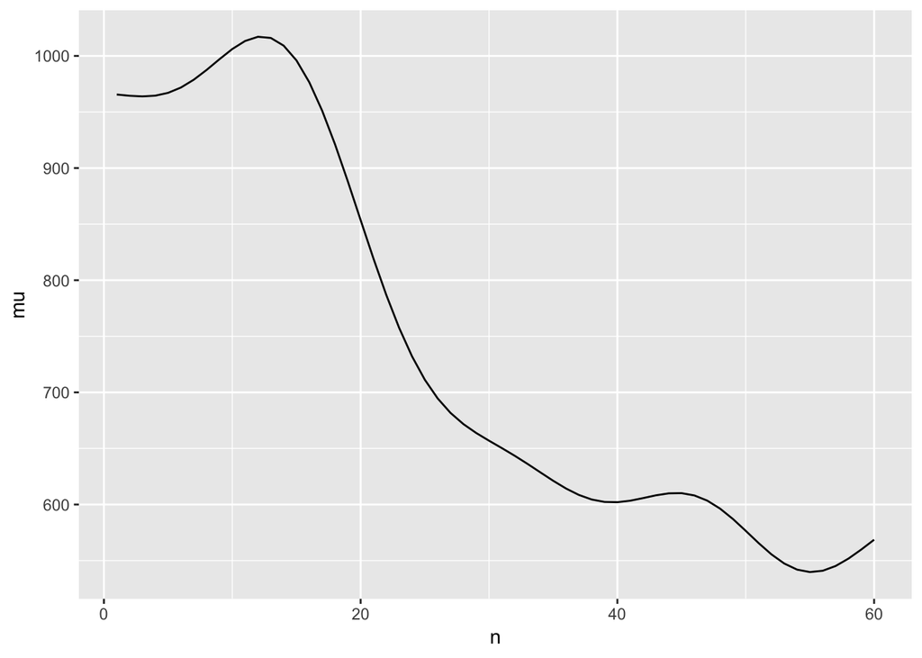

```r
## plot estimated mean function
ggplot(fit.mu, aes(x = n, y = mu)) + geom_path()
```

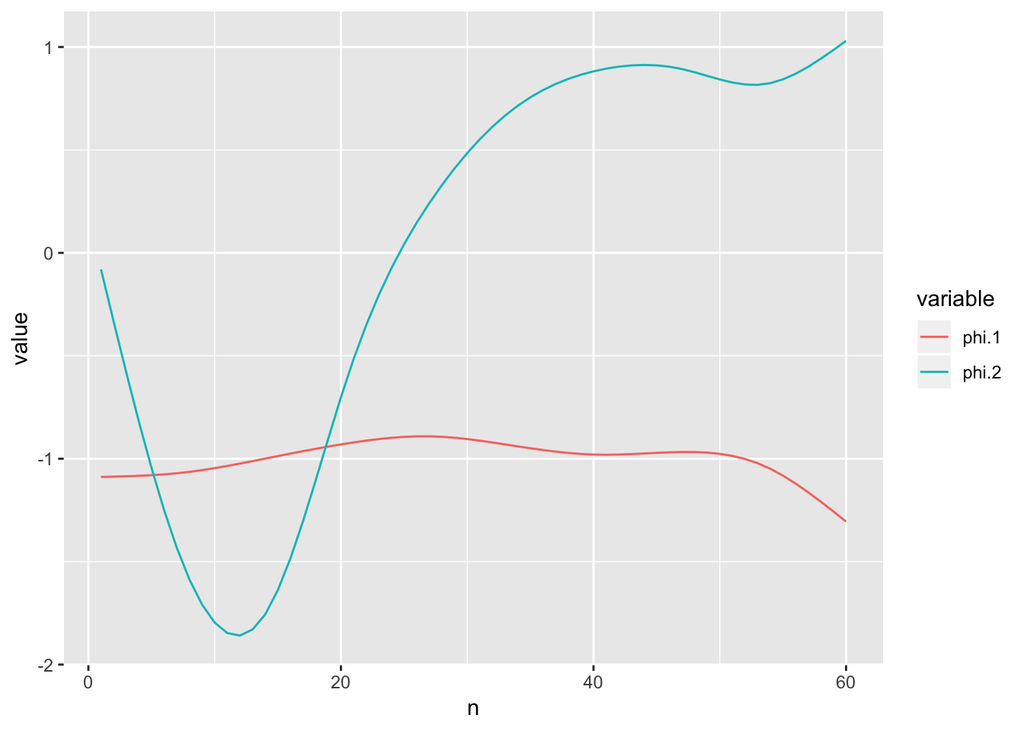

```r
## plot the first two estimated basis functions
fit.basis.m = melt(fit.basis, id = 'n')
ggplot(subset(fit.basis.m, variable %in% c('phi.1', 'phi.2')), aes(x = n,
y = value, group = variable, color = variable)) + geom_path()
```

## ols_cs_tfd()

### Description

(reference: https://github.com/refunders/refund/blob/master/R/OLS_CS.R)

Assuming that the response of the proposed model is a tfd class variable, it calls the response variable and alters it to be a matrix.

### Usage

ols_cs_tfd(formula, data=NULL, Kt=5, basis = “bs”, verbose = TRUE)

### Arguments

@param formula: a formula indicating the structure of the proposed model. Takes in tfd class variable as the response.

@param data: an optional data frame, list or environment containing the variables in the model. If not found in data, the variables are taken from environment(formula), typically the environment from which the function is called.

@param Kt: number of spline basis functions used to estimate coefficient functions

@param basis: basis type; options are “bs” for b-splines and “pbs” for periodic b-splines

@param verbose: logical defaulting to TRUE – should updates on progress be printed?

### Examples

Reading in DTI (`refund::DTI`) and dti, a data frame derived from DTI with two columns containing functional data (cca, rcst) in tfd class instead of matrices.

```r
DTI = refund::DTI

dti = with(refund::DTI,
  data.frame(id = ID, sex = sex,
             pasat = pasat,
    case = factor(ifelse(case, "MS", "control")))) %>% as.tbl %>%
        mutate(cca = tfd(DTI$cca, seq(0,1, l = 93), signif = 2) %>%
                     tfd(arg = seq(0,1,l = 93)),
               rcst = tfd(DTI$rcst, seq(0, 1, l = 55), signif = 3))
```

```r
source("./function/ols_cs_tfd.R")
```

```r
dti.ols = ols_cs_tfd(cca ~ pasat, data = dti, Kt = 10)
```

```
## Using OLS to estimate model parameters
```

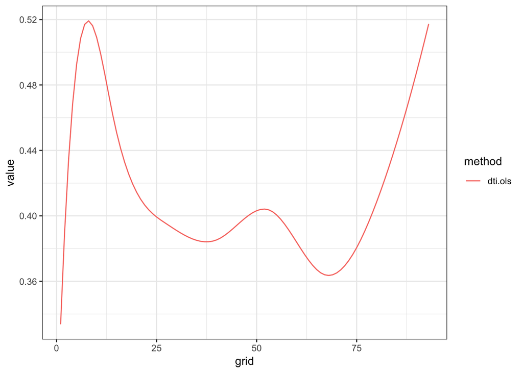

```r
models = c("dti.ols")
intercepts = sapply(models, function(u) get(u)$beta.hat[1,])
slopes = sapply(models, function(u) get(u)$beta.hat[2,])

# plotting estimated intercepts
plot.dat = melt(intercepts); colnames(plot.dat) = c("grid", "method", "value")
ggplot(plot.dat, aes(x = grid, y = value, group = method, color = method)) +
   geom_path() + theme_bw()
```

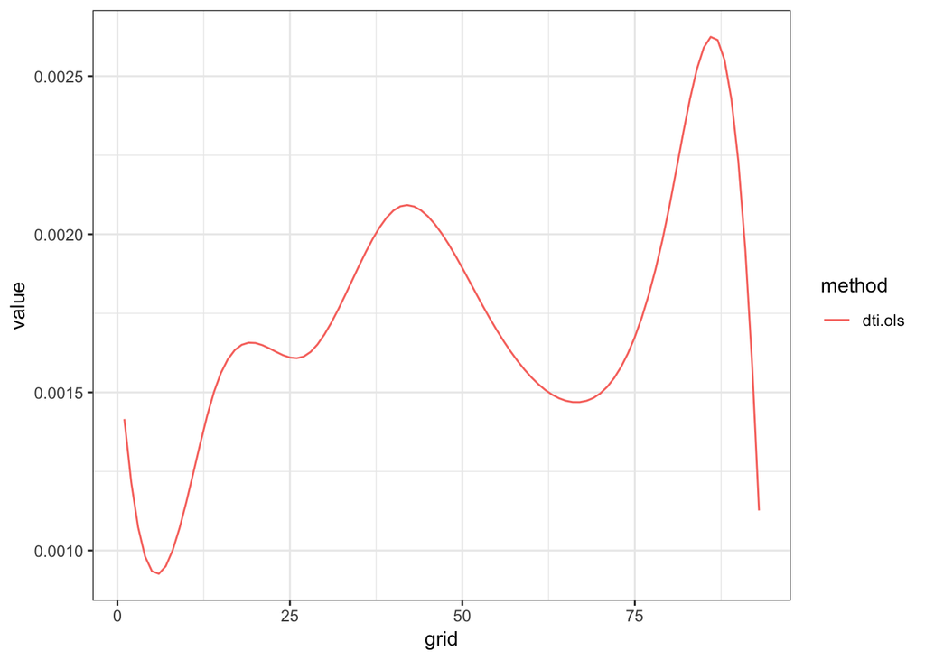

```r
# plotting estimated slopes
plot.dat = melt(slopes); colnames(plot.dat) = c("grid", "method", "value")
ggplot(plot.dat, aes(x = grid, y = value, group = method, color = method)) +
   geom_path() + theme_bw()
```